# NLP Exploratory Analisys

Daniel Villegas

March 19, 2016

# NLP Exploratory Analisys

## Introduction

Text produced by humans is a collection of words arranged in certain ways that they met some rules i.e. syntax, grammar, etc. and together are meaningful to other humans. Even though, all languages have rules that try to stablish how words should be used and how text should be written, there are cases when errors are made and sets of words that are meaningful do not follow some of the rules.

The meaning of a sentence or a text does not only relay on it´s structure, meaning also relies on experiences, culture, context, etc. Sentences such as “That sucks”, although it sounds like something negative, means nothing without previous knowledge of what it makes reference to. Another example may be sarcasm or irony, even some humans are not able to detect and understand them. The fact that a collection of words are arranged following all the rules that exist in the language, does not guarantee that every other human that speaks the language will be able to understand its meaning.

Language is not a fixed set of rules that organizes words in sentences, instead words are related together by a set of complex rules. Syntax and grammar are not enough to model these complex relationships, there may even be unknown relations and rules.

The main goal is to be able to predict, for a sentence, which word is most likely to be used next. To do this, it is necessary to create a mathematical model which describes the relations between words occuring in a sentence. A simple and maybe naive model would be to predict the next word given the set of syntactic rules that exist in a language, for example, “you” can be followed by a verb e.g. are, can, should, etc. This does not successfully model the next word because the set of words that can follow the word “you” is a very large set and under whis model, it is impossible to select which of them is more likely to come next.

An approach to model language complex relations, is to relay on the probability of a word occuring after one or more words, then, it would be possible to calculate how likely is for a sentence to happen.

## N-grams

N-grams are sets of N words that appear in some order. In a training set, the probability of each N-gram can be calculated by counting the number of time that it appears. As N, the number of words in a N-gram grows, the probability of each N-gram gets smaller compared with smaller N, also, the distribution of all N-grams tend to be more like an uniform distribution. On the other hand, for smaller values of N, the n-gram contains less information of the relation between words, the probability of each N-gram is larger and the distribution is less uniform.

Since the set of all words that exist in a language is a finite set (very large but finite), the set of N-grams for each N is also finite. Thus the set of N-grams found in a training set is also finite. Even though, in the development of a learning algorithm, as much of the information from the training set must be presserved, some N-grams do not contain useful information, a 4-gram such as “You car fly big”, might have probability of 0, in practical terms, it never occurs. An strategy to deal with cases where unlikely words are seen in a text must be implemented.

## Data Analisys

Here, only unigrams, bigrams and trigrams are going to be considered. Higher order unigrams do not occur frequently in the training set, thus the predictions based on them would look very simmilar to the text found in the training set.

### Imports and Utility Functions

```r
library(tm)
library(NLP)
library(ggplot2)
library(tidyr)
library(dplyr)
library(igraph)
library(networkD3)
library(pander)

read.HCC <- function(base.path, LOCALE="en_US", category, n.lines=-1L){
  paths <- lapply(LOCALE,function(loc){
    filename = paste(loc, category, "txt", sep=".")
    if(grepl("\\/$", base.path)){
      paste(base.path, paste(loc, filename, sep="/"), sep="")
    }else{
      paste(base.path, paste(loc, filename, sep="/"), sep="/")
    }
  })
  paths <- setNames(paths, LOCALE)
  files.HCC <- lapply(paths, function(pl){
    tmp<-lapply(pl, readLines, n=n.lines)
    setNames(tmp, category)
  })
  setNames(files.HCC, LOCALE)
}

add_pstart_pstop_tags <- function(x){
  paste('PSTART',x,'PSTOP', sep=" ")
}

profanity_tag <- function(x, profanities){
    sapply(x, function(y){if(y %in% profanities){
      return('<PROF>')
    }
      return(y)})

}
```

### Getting the Data

Here the data is read from the file and converted into a corpus using the tm (Text Mining) library. Due to the size of the files, only a limited number of data will be used during this stage of the project.

```r
HCCcorpus <- read.HCC(base.path = '../../data/LOCALE/', category=c('twitter', 'news', 'blogs'), n.lines = 10000)
v.corpus <- unlist(HCCcorpus)

corpus <- data.frame(names=attributes(v.corpus),
                     text=v.corpus) %>%
  separate(names, into = c('locale', 'category'), sep='\\.') %>%
  mutate(category = sapply(category, gsub, pattern='[0-9]+', replacement=''),
         text=as.character(text))
corpus$nwords <- sapply(gregexpr("\\W+", corpus$text), length) + 1
vcorp <- VCorpus(x=VectorSource(corpus$text))


prof <- readLines("../../data/profanities.txt")
```

### Document Summary

The number of lines per document i.e. tweets, news and blogs. was limited to 10000. Here, a brief summary of the documents is presented.

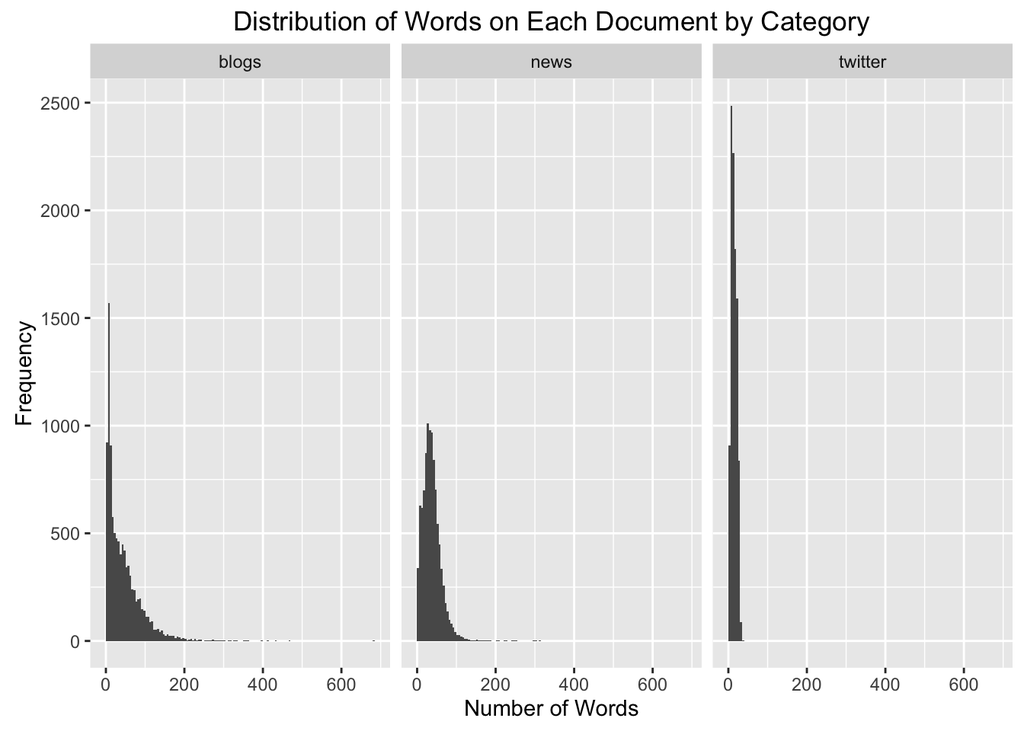

```r
ggplot(corpus, aes(x=nwords)) +
  geom_histogram(binwidth = 5) +
  facet_grid(.~category) +
  xlab('Number of Words') +
  ylab('Frequency') +
  ggtitle('Distribution of Words on Each Document by Category')
```

```r
out <- corpus %>%
  dplyr::group_by(category) %>%
  dplyr::summarise(Total = sum(nwords, na.rm=T),
                   Average=mean(nwords, na.rm=T),
                   'Standard Deviation'=sd(nwords, na.rm=T))
pander(out)
```

| category | Total | Average | Standard Deviation |
| --- | --- | --- | --- |
| blogs | 430507 | 43.0507 | 44.566756 |
| news | 367758 | 36.7758 | 23.797356 |
| twitter | 137816 | 13.7816 | 7.207447 |

### Data Cleaning and Preprocessing

The steps involved in the data cleaning and preprocessing are shown below.

1. Strip Whitespace removes any leading and trailing whitespaces for each document.
2. All the words in the document are converted to lowercase. This step will reduce the number of tokens and thus the number of N-grams.
3. Stop words are removed. This step has some consequences, some trigams that involve words from the stopwords set, are converted into bigrams and bigrams involving stop words are converted to unigrams. Even though some information is lost, most of it is related to syntactic rules.
4. Stem the document. This step converts words that are closely related to a single word, e.g. cars is converted to car.
5. Add document start and stop tags to each document. This step will help the algorithm to stablish the probability of the first word in a sentence, further improvements should be made in order to consider the effect of punctuation marks rather than the begining and end of a document.
6. Tokenization of the document using the MC_tokenizer included with the tm library.
7. Strings of length zero are removed, no actual information in lost, strings with length zero are just an artifact introduced by the algorithm.
8. Profanisties, rather than removed, are tagged.
9. Unigrams, bigrams and trigrams are extracted from the text.

```r
vcorp <- tm_map(vcorp, stripWhitespace)
vcorp <- tm_map(vcorp, content_transformer(tolower))
vcorp <- tm_map(vcorp, removeWords, stopwords('english'))
vcorp <- tm_map(vcorp, stemDocument, language='english')
vcorp <- tm_map(vcorp, content_transformer(add_pstart_pstop_tags))
tk_corp <- tm_map(vcorp, content_transformer(MC_tokenizer))
tk_corp <- tm_map(tk_corp, content_transformer(function(x){x[x!=""]}))
tk_corp <- tm_map(tk_corp, content_transformer(profanity_tag), profanities=prof)
bigram_corp <- tm_map(tk_corp, content_transformer(ngrams), 2)
trigram_corp <- tm_map(tk_corp, content_transformer(ngrams), 3)
```

Then, having all the N-grams, the next step is to get the probability for each one, based on the number of times it appears on the corpus.

Since the idea behind the start and stop tags is to estimate how likely is for a word to appear as the first or last word in the text, such tags are removed from the unigrams, otherwise a confounding relation between the size of the corpus (number of documents) and the frequency of the unigrams would be introduced. For a more comprehensive tokenization method e.g. a method that involves tagging punctuation marks, this might not hold.

```r
unigrams <- data.frame(unigram=unlist(sapply(tk_corp, function(x){
  x$content
}))) %>%
  dplyr::filter(unigram!='PSTOP',unigram!='PSTART') %>%
  dplyr::group_by(unigram) %>%
  dplyr::summarise(cnt=n()) %>%
  ungroup() %>%
  mutate(w0=as.character(unigram), p = cnt / sum(cnt)) %>%
  select(w0, cnt, p) %>%
  dplyr::arrange(desc(cnt))

bigrams <- data.frame(bigram=unlist(sapply(bigram_corp, function(x){
  x$content
})))  %>%
  mutate(bigram=sapply(as.character(bigram), function(x) substr(x, 4, nchar(x)-2))) %>%
  separate(bigram, into=c('w0', 'w1'), sep = "\", \"") %>%
  dplyr::group_by(w0, w1) %>%
  dplyr::summarise(cnt=n()) %>%
  ungroup() %>%
  inner_join(y=unigrams, by='w0') %>%
  mutate(p = cnt.x / cnt.y) %>%
  dplyr::ungroup() %>%
  dplyr::mutate(cnt=cnt.x) %>%
  dplyr::select(w0, w1, cnt, p) %>%
  dplyr::arrange(desc(p))

trigrams <- data.frame(trigram=unlist(sapply(trigram_corp, function(x){
  x$content
}))) %>%
  mutate(trigram=sapply(as.character(trigram), function(x) substr(x, 4, nchar(x)-2))) %>%
  separate(trigram, into=c('w0', 'w1', 'w2'), sep = "\", \"")  %>%
  dplyr::group_by(w0, w1, w2) %>%
  dplyr::summarise(cnt=n()) %>%
  ungroup() %>%
  inner_join(y=bigrams, by=c("w0" = "w0", "w1" = "w1")) %>%
  mutate(p = cnt.x / cnt.y) %>%
  dplyr::ungroup() %>%
  dplyr::mutate(cnt=cnt.x) %>%
  dplyr::select(w0, w1, w2, cnt, p) %>%
  dplyr::arrange(desc(p))
```

### Unigrams

In this section, some statistical properties of the unigrams are going to be examined. The mean probability of finding an unigram is `2.4e-05` and the standard deviation `0.00016`. The 20 most frequent unigrams are shown below.

```r
panderOptions("digits", 2)
pander(head(unigrams %>%
              mutate(w0 = sapply(as.character(w0),
                                 function(x) ifelse(x=='<PROF>',
                                                    'Profanities',
                                                    x))) %>%
              transmute(Word=w0, Frequency=cnt, Probability=p), n = 20))
```

| Word | Frequency | Probability |
| --- | --- | --- |
| Profanities | 8781 | 0.018073554 |
| said | 2943 | 0.006057450 |
| will | 2777 | 0.005715779 |
| one | 2749 | 0.005658148 |
| just | 2382 | 0.004902768 |
| like | 2378 | 0.004894535 |
| can | 2263 | 0.004657835 |
| get | 2237 | 0.004604321 |
| time | 2160 | 0.004445835 |
| go | 2000 | 0.004116514 |
| year | 1943 | 0.003999193 |
| s | 1941 | 0.003995077 |
| make | 1733 | 0.003566959 |
| new | 1602 | 0.003297328 |
| day | 1560 | 0.003210881 |
| know | 1421 | 0.002924783 |
| now | 1398 | 0.002877443 |
| love | 1393 | 0.002867152 |
| t | 1375 | 0.002830103 |
| work | 1360 | 0.002799229 |

Profanities seem to be very popular, appart from profanities, some common words can be seen in the table.

The figure below shows the distribution of the probabilities for unigrams.

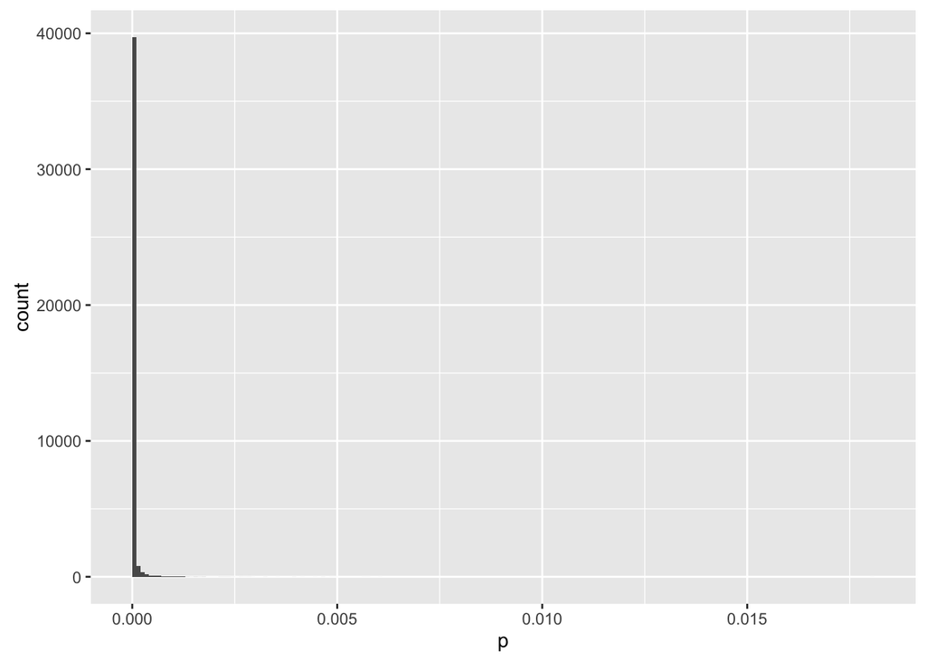

```r
ggplot(unigrams , aes(x=p)) + geom_histogram(binwidth = 0.0001)
```

### Bigrams

In this section, some statistical properties of the bigrams are going to be examined. The mean probability of finding an bigram is `0.11` and the standard deviation `0.24`.

```r
panderOptions("digits", 2)
pander(head(bigrams %>%
              mutate(w0 = sapply(as.character(w0),
                                 function(x) ifelse(x=='<PROF>',
                                                    'Profanities',
                                                    x)),
                     w1 = sapply(as.character(w1),
                                 function(x) ifelse(x=='<PROF>',
                                                    'Profanities',
                                                    x))) %>%
              transmute(Word0=w0, Word1=w1, Frequency=cnt, Probability=p),
            n = 20))
```

| Word0 | Word1 | Frequency | Probability |
| --- | --- | --- | --- |
| aaaa | can | 1 | 1 |
| aaaaaand | noth | 1 | 1 |
| aaaagggghhhh | PSTOP | 1 | 1 |
| aaawww | man | 1 | 1 |
| aachen | germany | 1 | 1 |
| aadil | palkhivala | 1 | 1 |
| aaggh | tri | 1 | 1 |
| aahs | PSTOP | 1 | 1 |
| aaiight | PSTOP | 1 | 1 |
| aamoth | new | 1 | 1 |
| aand | much | 1 | 1 |
| aang | katara | 1 | 1 |
| aarp | statistics | 1 | 1 |
| aasif | mandvi | 1 | 1 |
| aasl | convetion | 1 | 1 |
| aba | star | 1 | 1 |
| aback | aborigin | 1 | 1 |
| abakanowicz | agora | 1 | 1 |
| abbasiyah | emerg | 1 | 1 |
| abbhor | vacuum | 1 | 1 |

The figure below shows the distribution of the probabilities for bigrams.

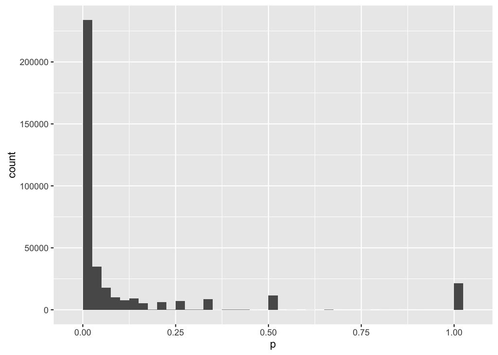

```r
ggplot(bigrams , aes(x=p)) + geom_histogram(bins=40)
```

### Trigrams

```r
panderOptions("digits", 2)
pander(head(trigrams %>%
              mutate(w0 = sapply(as.character(w0),
                                 function(x) ifelse(x=='<PROF>',
                                                    'Profanities',
                                                    x)),
                     w1 = sapply(as.character(w1),
                                 function(x) ifelse(x=='<PROF>',
                                                    'Profanities',
                                                    x)),
                     w2 = sapply(as.character(w2),
                                 function(x) ifelse(x=='<PROF>',
                                                    'Profanities',
                                                    x))) %>%
              transmute(Word0=w0, Word1=w1, Word2=w2,
                        Frequency=cnt, Probability=p),
            n = 20))
```

| Word0 | Word1 | Word2 | Frequency | Probability |
| --- | --- | --- | --- | --- |
| Profanities | ab | alreadi | 1 | 1 |
| Profanities | abdulaziz | believ | 1 | 1 |
| Profanities | abl | deal | 1 | 1 |
| Profanities | aboard | democrat | 1 | 1 |
| Profanities | abolisheth | Profanities | 1 | 1 |
| Profanities | absinth | vert | 1 | 1 |
| Profanities | academi | location | 1 | 1 |
| Profanities | accident | clear | 1 | 1 |
| Profanities | accidents | unproven | 1 | 1 |
| Profanities | accompani | guitar | 1 | 1 |
| Profanities | accomplish | cross | 1 | 1 |
| Profanities | accus | otha | 1 | 1 |
| Profanities | acres | data | 1 | 1 |
| Profanities | acryl | paint | 1 | 1 |
| Profanities | act | can | 1 | 1 |
| Profanities | action | pact | 1 | 1 |
| Profanities | actions | PSTOP | 1 | 1 |
| Profanities | activities | consum | 1 | 1 |
| Profanities | activity | PSTOP | 1 | 1 |
| Profanities | actually | thing | 1 | 1 |

The figure below shows the distribution of the probabilities for trigrams.

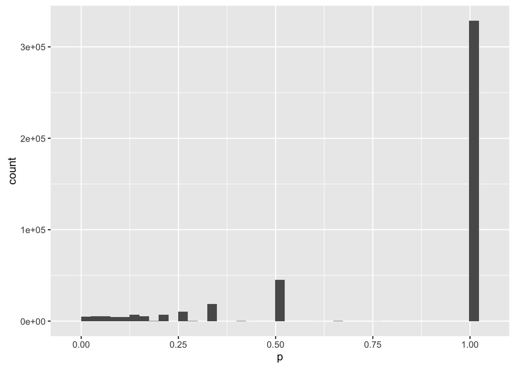

```r
ggplot(trigrams , aes(x=p)) + geom_histogram(bins=40)
```

### Analisys on N-grams Distributions

One of the asumptions about the N-grams was that, as N grows, the distribution of the N-grams would be more uniform than those for smaller values of N.

The set of N-grams is by definition disorganized i.e. the the concept of greater than and smaller than are not well defined in the N-gram sets as they are in sets such as the integer numbers. For this reason, it is not possible to compare the distribution of the N-grams for a given N with a known distribution using qq-plots. Instead it is necessary to inspect the probabilities of each N-gram and compare them with the theoretical properties of the distribution of probabilities generated by a random distribution.

Let $x$ be an uniformly distributed random variable, then, for each $x$, the frequency would be $k$, and the probabilities are proportional to $\frac{k}{\sum{k}}$. The distribution of the probabilities of $x$ would have an standard deviation equal or very close to zero, and would have a unique peak in $k$ or $\frac{k}{\sum{k}}$, respectively. On the other hand, a non uniform distribution would have frequencies with a larger standard deviation and more than one peak.

### Bigram Graph

Unigrams do not contain information about the relation between word, bigrams show relations between pairs of words and higher order N-grams model more complex word associations.

Below, a graph created from the bigrams is presented.

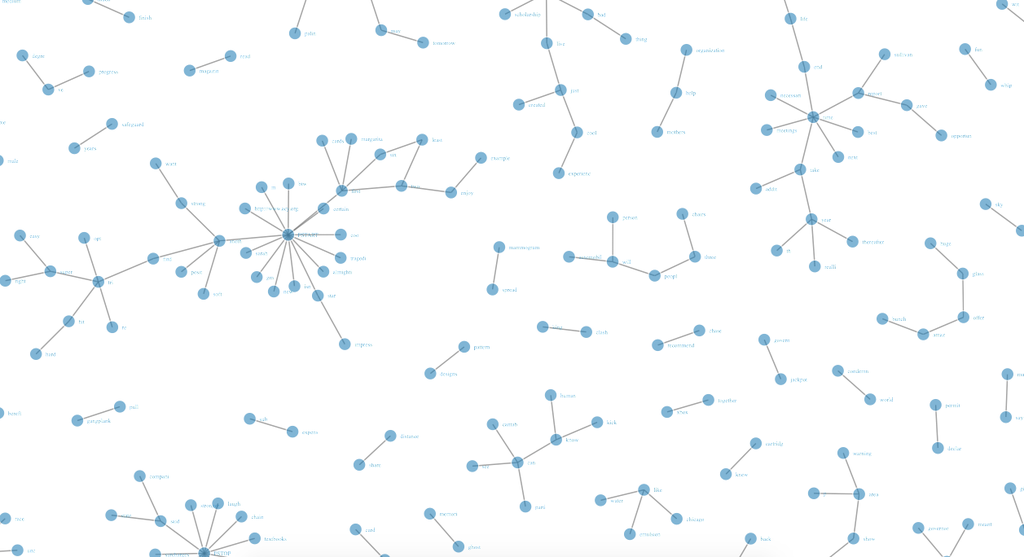

It can be seen in the figure above, how the formation of higher order N-grams are done by using the associations containd in bigrams. The weight of each path is derived from the propability of each bigram.

The graph was produced with a small sample of the bigrams, nevertheless, the network produced by all the possible bigrams in the training set would also be a collection of disconnected graphs. The consequence of having disconected graphs is that, a learning algorithm that would try to guess the next most likely word to occur would encounter nodes where there are no more possibilities. The learning algorithm would then need to be implemented with a way to connect those unconnected graphs with small probablity links that are derived from the training set but that may have not been seen during the training process.

```r
bigrams2 <- bigrams[c(sample(1:1000, 500),
                      sample(1001:nrow(bigrams), 500)),]
simpleNetwork(data.frame(bigrams2$w0, bigrams2$w1))
```

[interactive chart not shown]

The second graph is a much more complex, interactive graph is presented above, the intention is to show how relations change when a larger number of bigrams is used.

#### Betweenness Centrality

```r
bigram_graph <- graph.data.frame(bigrams %>%
                                   mutate(weight=p) %>%
                                   select(w0,w1,weight), directed = T)
```

```r
btnc<-as.data.frame(betweenness(bigram_graph))
btnc$Word <- rownames(btnc)
colnames(btnc)[1] <- 'Betweenness'
btnc <- btnc %>%
  mutate(Word = sapply(as.character(Word),
                     function(x) ifelse(x=='<PROF>',
                                        'Profanities',
                                        x))) %>%
  arrange(desc(Betweenness)) %>%
  select(Word, Betweenness)
  pander(head(btnc))
```

| Word | Betweenness |
| --- | --- |
| Profanities | 2.2e+08 |
| said | 1.6e+08 |
| will | 1.1e+08 |
| like | 1.1e+08 |
| one | 1e+08 |
| s | 8.4e+07 |

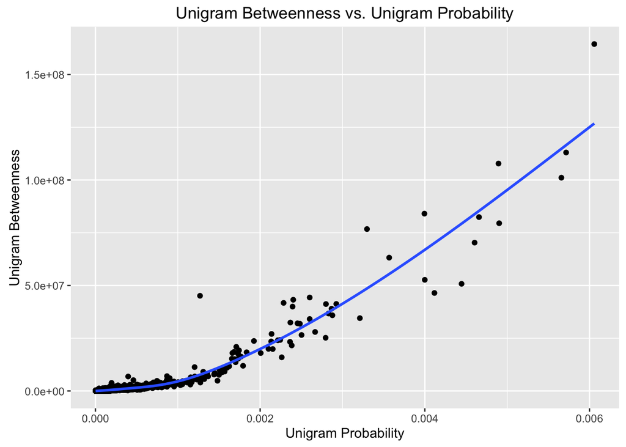

```r
  ggplot(inner_join(btnc, unigrams %>% mutate(Word=w0), by='Word'),
         aes(x=p, y=Betweenness)) +
    geom_point() +
    geom_smooth() +
    xlab('Unigram Probability') +
    ylab('Unigram Betweenness') +
    ggtitle('Unigram Betweenness vs. Unigram Probability')
```

### Further Work on Trigrams

It is not easy to see why higher order N-grams is useful. distributions are mostly uniform i.e. most N-grams are equaly likely to happen. In this section a discussion is performed in order to gain some insight on the trigrams.

As mentioned in the previous sections, the distribution of the trigrams is nearly uniform, the issue with this is that most trigrams are equaly likely to ocur. By the nature of the trigrams i.e. it´s structure, trigrams may be useful to model words that relate pairs of words, for example, in the sentence “You can travel by car, bycicle, motorcycle, airplanes and <unknown>”, it is not likely that the next word would be “apples”, “bus” or “train” are more likely to occur instead. The bigram “and” - “<unknown>”, trying to predict the next word would have no knowledge of the items being listed, then, “apples” would be likely to occur. On the other hand the incomplete trigram “airplanes” - “and” - “<unknown>” would have knowledge of the one of the items being listed, therefore it might predict the next word better than the bigram by itself.

If the subset of N-grams for a given N that are related to a syntactic structure such as a list are filtered, it might be possible to create algorithms may have a better knowledge of the context of the sentence.

## Conclusions

- Given the strong influence of profanities, such words should be handled by the learning algorithm rather than being discarded from the training set.
- As N becomes larger, N-gram distributions become more uniform.
- A more efficient way of handling the large datasets will have to be implemented for the shiny app.
- A strong relation between centrality measure of nodes from the bigram graph and the unigram probabilities was found. Such relation shows that in a way, the set of all bigrams preserves information about the set of all unigrams. The relationship found and other relations based on graph measures might be useful to create new features for the learning algorithm.